# Financial Data Modeling: i.i.d. Case

Prof. Daniel P. Palomar

Python code: [Zé Vinícius](https://github.com/mirca) R code: [Prof. Daniel Palomar](https://github.com/dppalomar) IEDA/ELEC3180 - Data-Driven Portfolio Optimization The Hong Kong University of Science and Technology (HKUST) Spring 2022-23

This Python session will explore the i.i.d. financial models, starting from the basics and exploring more advanced topics like shrinkage estimators and robust estimators to heavy tails.

# Financial data

We will now explore financial data to see whether it is really heavy-tailed.

Let’s load the S&P 500 index:

```python
import yfinance as yf
sp500 = yf.download("^GSPC", start = "2010-01-01", end = "2015-12-31")
#>
[*********************100%***********************]  1 of 1 completed
sp500['Close'].head()
#> Date
#> 2010-01-04 00:00:00-05:00    1132.989990
#> 2010-01-05 00:00:00-05:00    1136.520020
#> 2010-01-06 00:00:00-05:00    1137.140015
#> 2010-01-07 00:00:00-05:00    1141.689941
#> 2010-01-08 00:00:00-05:00    1144.979980
#> Name: Close, dtype: float64
sp500['Close'].tail()
#> Date
#> 2015-12-23 00:00:00-05:00    2064.290039
#> 2015-12-24 00:00:00-05:00    2060.989990
#> 2015-12-28 00:00:00-05:00    2056.500000
#> 2015-12-29 00:00:00-05:00    2078.360107
#> 2015-12-30 00:00:00-05:00    2063.360107
#> Name: Close, dtype: float64
```

Let’s do some plotting:

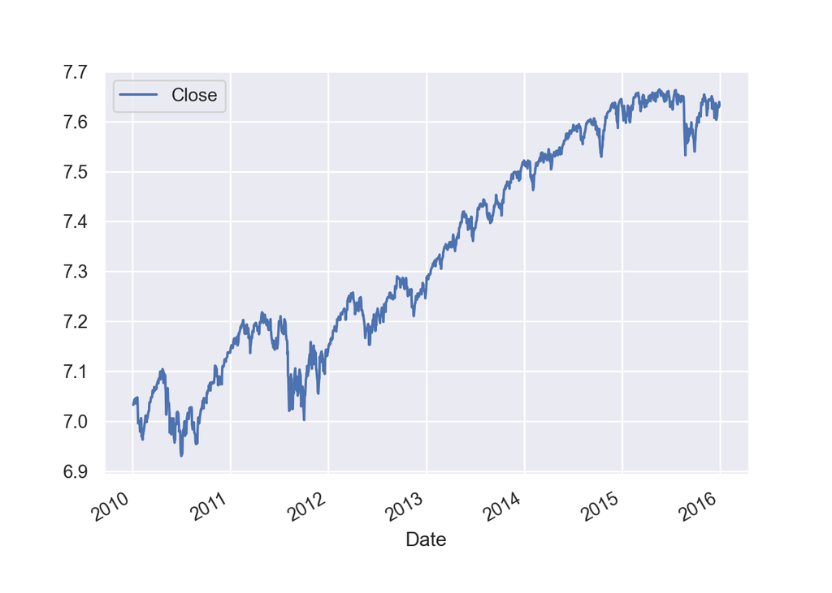

```python
import seaborn as sns
sns.set(style="darkgrid")
import numpy as np
import matplotlib.pyplot as plt

close_prices = sp500[['Close']]
# plot log-prices
log_prices = close_prices.apply(np.log)  # also: log_prices = np.log(close_prices)
log_prices.plot()
#> <AxesSubplot: xlabel='Date'>
plt.show()
```

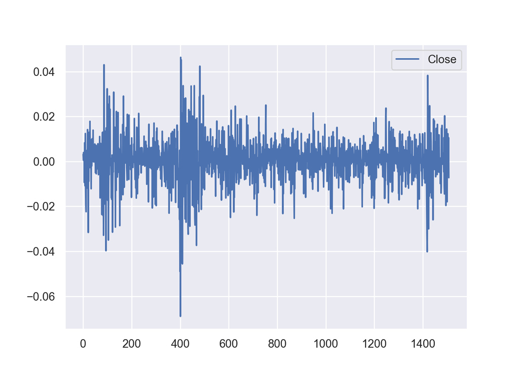

```python
# plot log-returns
log_returns = log_prices.apply(np.diff)
log_returns.plot()
#> <AxesSubplot: >
plt.show()
```

Now, let’s see how heavy the tails are:

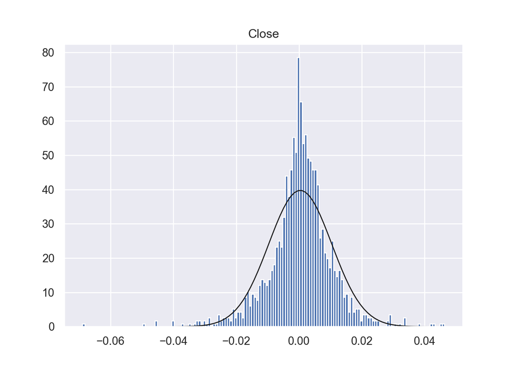

```python
# histogram to illustrate heavy-tails and gain/loss asymmetry
from scipy.stats import norm

mu, std = norm.fit(log_returns) # fit a gaussian to the log returns
xmin, xmax = log_returns.min(), log_returns.max()
x = np.linspace(xmin, xmax, 100)
p = norm.pdf(x, mu, std) # evaluate gaussian pdf
log_returns.hist(bins=150, density=True) # plot histogram
#> array([[<AxesSubplot: title={'center': 'Close'}>]], dtype=object)
plt.plot(x, p, 'k', linewidth=1) # plot estimated pdf
#> [<matplotlib.lines.Line2D object at 0x7f782a953cd0>]
plt.show()
```

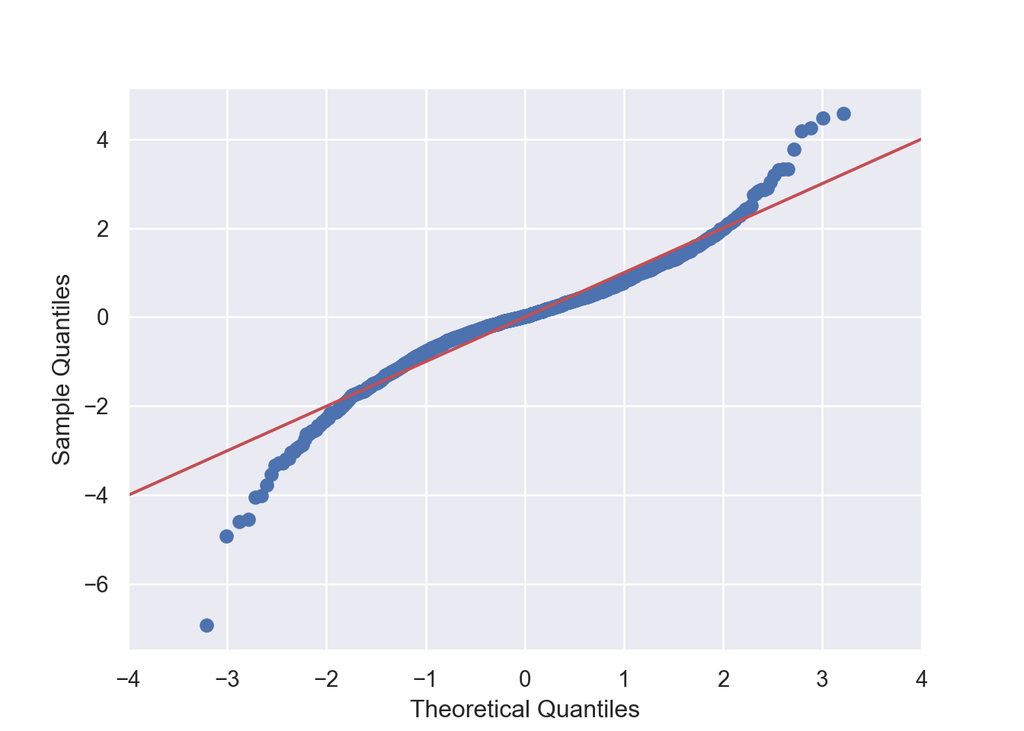

```python
import statsmodels.api as sm

# QQ plot
fig = plt.figure()
ax = fig.add_subplot()
sm.graphics.qqplot(np.array(log_returns['Close']), line='45', fit=True, ax=ax)
#> <Figure size 700x500 with 1 Axes>
ax.set_xlim(-4, 4)
#> (-4.0, 4.0)
plt.show()
```

We can conclude that financial data is clearly heavy-tailed. Therefore, using the classical sample estimators is probably going to be pretty bad, which we will explore next.

# Classical estimators

Let’s warm up using the classical estimators for the mean and covariance matrix, namely the sample mean and the sample covariance matrix:
$$\begin{aligned}
\boldsymbol{\mu} & = \frac{1}{T}\sum_{t=1}^T\mathbf{x}_t\\
\boldsymbol{\Sigma} & =
\frac{1}{T-1}\sum_{t=1}^T(\mathbf{x}_t-\boldsymbol{\mu})(\mathbf{x}_t-\boldsymbol{\mu})^T.
\end{aligned}$$

```python
# generate Gaussian synthetic return data
import numpy as np

np.random.seed(42)
N = 200
T = 500
mu = np.zeros(N)
U = np.random.multivariate_normal(mean=mu, cov=0.1*np.eye(N), size=round(.7*N)).T
Sigma_cov = U @ U.T + np.eye(N)
X = np.random.multivariate_normal(mean=mu, cov=Sigma_cov, size=T)

mu_classical = np.mean(X, axis=0) # classical mean estimator (sample mean)
np.linalg.norm(mu_classical - mu)
#> 2.2388459756304293
Sigma_classical = np.cov(X.T) # classical covariance estimator (sample covariance matrix)
np.linalg.norm(Sigma_classical - Sigma_cov) / np.linalg.norm(Sigma_cov)
#> 0.43096917656413286
```

## Data with outliers

Now, let’s add some of outliers in the data and see how the performance degrades significantly.

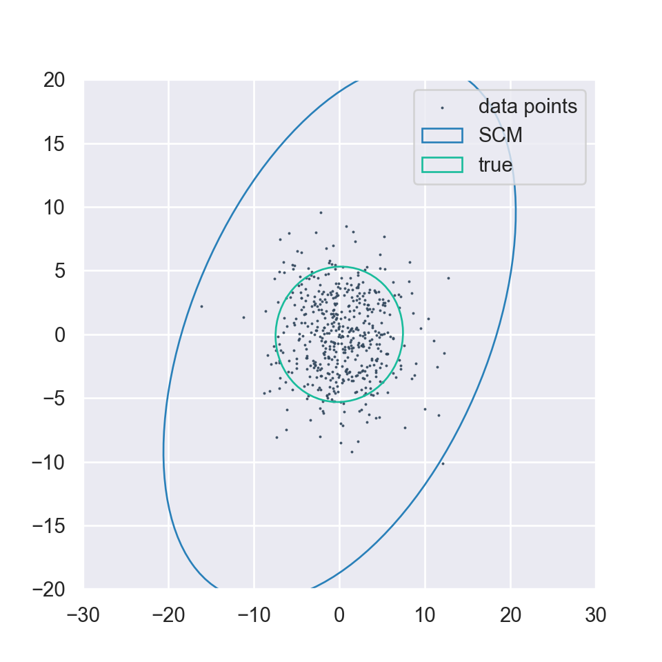

```python
np.random.seed(42)

# keep two variables for the 2D scatter plots
i1 = 0
i2 = 1
X = X[:, [i1, i2]]
N = X.shape[1]

# introduce outliers
num_outliers = round(0.05*T)
X_outliers = np.copy(X) # remember to copy numpy arrays if you want to keep the original intact
t_indices = np.random.choice(np.arange(T), size=num_outliers)
n_indices = np.random.choice(np.arange(N), size=num_outliers, replace=True)
ave_std = np.sqrt(np.mean(np.diag(np.cov(X.T))))
X_outliers[np.column_stack([t_indices, n_indices])] = 2*ave_std*X_outliers[np.column_stack([t_indices, n_indices])]
Sigma_scm    = np.cov(X_outliers[:50,:].T)

# define function to draw an ellipse from a covariance matrix
def confidence_ellipse(cov, mean, ax, facecolor='none', **kwargs):
    from matplotlib.patches import Ellipse
    import matplotlib.transforms as transforms
    values, vectors = np.linalg.eig(cov)
    angle = np.arccos(vectors[0, 0]) * 180 / np.pi
    ellipse = Ellipse((mean[0], mean[1]),
        width=values[0],
        height=values[1],
        facecolor=facecolor,
        **kwargs)
    mean_x, mean_y = mean
    transf = transforms.Affine2D().rotate_deg(angle)
    ellipse.set_transform(transf + ax.transData)
    return ellipse

fig, ax = plt.subplots(figsize=(5, 5))
ax.scatter(X[:, 0], X[:, 1], color='#34495e', s=.2, label='data points')
#> <matplotlib.collections.PathCollection object at 0x7f782ae83010>
ax.add_patch(confidence_ellipse(Sigma_scm, np.mean(X_outliers, axis=0), ax, edgecolor='#2980b9', label='SCM'))
#> <matplotlib.patches.Ellipse object at 0x7f782ae82ce0>
ax.add_patch(confidence_ellipse(Sigma_cov[0:2, 0:2], [0, 0], ax, edgecolor='#1abc9c', label='true'))
#> <matplotlib.patches.Ellipse object at 0x7f782ae83430>
ax.set_xlim([-30, 30])
#> (-30.0, 30.0)
ax.set_ylim([-20, 20])
#> (-20.0, 20.0)
plt.legend()
#> <matplotlib.legend.Legend object at 0x7f782ae83c10>
plt.show()
```

## Heavy-tailed data

Let’s now generate heavy-tailed synthetic data and see the performance of the classical sample estimators.

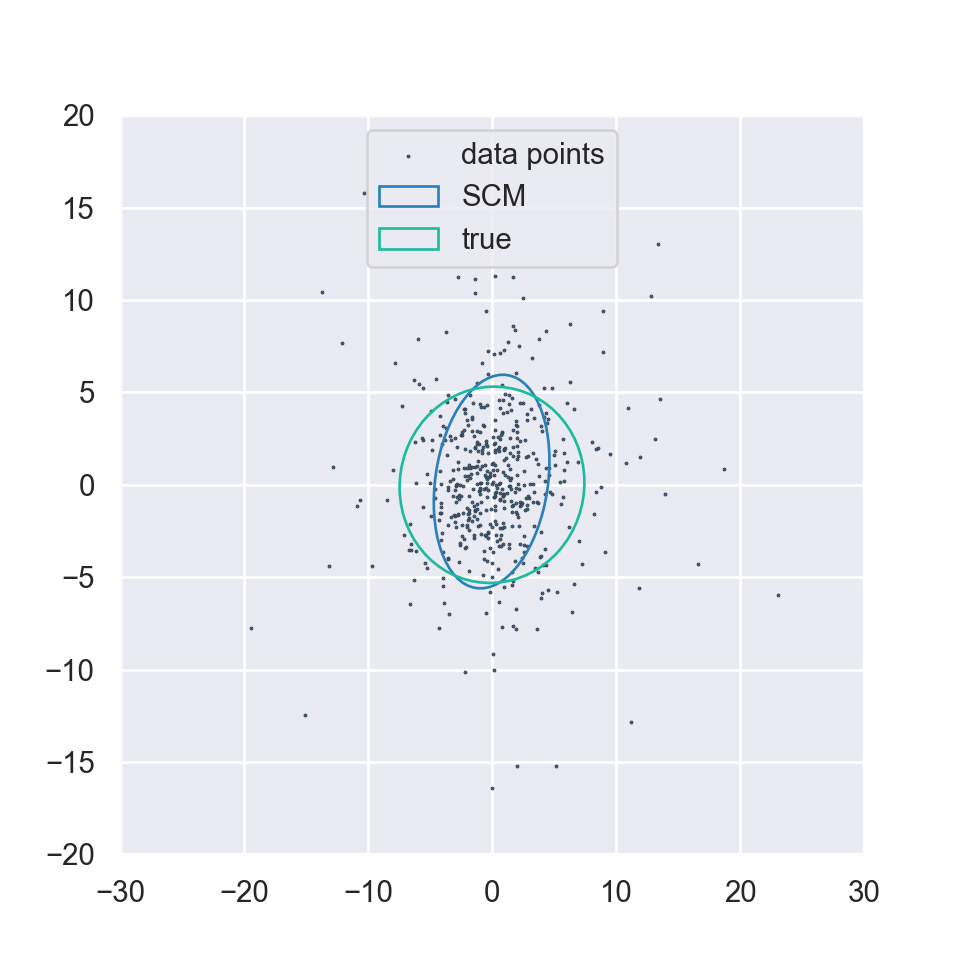

```python
np.random.seed(42)
# generate heavy-tailed synthetic return data
nu = 4  # degrees of freedom (measures how heavy the tail is)
N = 200
T = 500
mu = np.zeros(N)
U = np.random.multivariate_normal(mean=mu, cov=0.1*np.eye(N), size=round(.7*N)).T
Sigma_cov = U @ U.T + np.eye(N)

def multivariate_t(mean, cov, nu=np.inf, size=1):
    '''generate random variables of multivariate t distribution
    '''
    mean = np.asarray(mean)
    d = len(mean)
    if nu == np.inf:
        x = 1.
    else:
        x = np.random.chisquare(nu, size) / nu
    z = np.random.multivariate_normal(np.zeros(d), cov, (size,))
    return mean + z/np.sqrt(x)[:,None]

X = multivariate_t(mean=mu, cov=(nu-2)/nu*Sigma_cov, nu=nu, size=T)

# classical mean estimators
mu_classical = np.mean(X, axis=0)
np.linalg.norm(mu_classical - mu)
#> 2.33578097421874
Sigma_classical = np.cov(X.T)
np.linalg.norm(Sigma_classical - Sigma_cov) / np.linalg.norm(Sigma_cov)

# keep two variables for the 2D scatter plots
#> 0.7054800812539801
i1 = 2
i2 = 180
X = X[:, [i1, i2]]
N = X.shape[1]
Sigma_scm    = np.cov(X[:20,:].T)

# scatter plot
fig, ax = plt.subplots(figsize=(5, 5))
ax.scatter(X[:, 0], X[:, 1], color='#34495e', s=.2, label='data points')
#> <matplotlib.collections.PathCollection object at 0x7f782b516830>
ax.add_patch(confidence_ellipse(Sigma_scm, np.mean(X_outliers, axis=0), ax, edgecolor='#2980b9', label='SCM'))
#> <matplotlib.patches.Ellipse object at 0x7f782b516440>
ax.add_patch(confidence_ellipse(Sigma_cov[0:2, 0:2], [0, 0], ax, edgecolor='#1abc9c', label='true'))
#> <matplotlib.patches.Ellipse object at 0x7f782b516b60>
ax.set_xlim([-30, 30])
#> (-30.0, 30.0)
ax.set_ylim([-20, 20])
#> (-20.0, 20.0)
plt.legend()
#> <matplotlib.legend.Legend object at 0x7f782b517340>
plt.show()
```

# Factor models

## Macroeconomic factor model

### Single market factor

We will start with a simple example consisting of a single known factor (i.e., the market index). The model is
$$\mathbf{x}_t = \boldsymbol{\alpha} + \boldsymbol{\beta}f_t +
\boldsymbol{\epsilon}_t, \quad t=1,\ldots,T$$
where the explicit factor $f_t$ is the S&P 500 index. We will do a simple least squares (LS) regression to estimate the intercept $\boldsymbol{\alpha}$ and the loading beta $\boldsymbol{\beta}$:
$$\underset{\boldsymbol{\alpha},\boldsymbol{\beta}}{\text{minimize}}\quad
\sum_{t=1}^T\|\mathbf{x}_t - \boldsymbol{\alpha} -
\boldsymbol{\beta}f_t\|^2$$

Most the code lines go into preparing the data rather than actually performing the factor modeling. Let’s start getting the data ready:å

```python
import yfinance as yf

begin_date = "2016-01-01"
end_date = "2017-12-31"
stock_namelist = ["AAPL", "AMD", "ADI",  "ABBV", "AEZS", "A",  "APD", "AA","CF"]
dataset = yf.download(stock_namelist, start = begin_date, end = end_date)   # <--- this fails
#>
[                       0%                       ]
[***********           22%                       ]  2 of 9 completed
[****************      33%                       ]  3 of 9 completed
[********************* 44%                       ]  4 of 9 completed
[**********************56%**                     ]  5 of 9 completed
[**********************67%*******                ]  6 of 9 completed
[**********************78%************           ]  7 of 9 completed
[**********************89%******************     ]  8 of 9 completed
[*********************100%***********************]  9 of 9 completed
dataset.head()
#>                            Adj Close             ...   Volume
#>                                    A         AA  ...      APD       CF
#> Date                                             ...
#> 2016-01-04 00:00:00-05:00  38.411514  22.788774  ...  1427244  3262500
#> 2016-01-05 00:00:00-05:00  38.279346  21.756123  ...  1465512  2690000
#> 2016-01-06 00:00:00-05:00  38.449280  20.207142  ...  1610690  4711800
#> 2016-01-07 00:00:00-05:00  36.816143  19.409180  ...  4264329  5010600
#> 2016-01-08 00:00:00-05:00  36.429115  18.939793  ...  2785953  4130100
#>
#> [5 rows x 54 columns]
dataset.tail()
#>                            Adj Close             ...  Volume
#>                                    A         AA  ...     APD       CF
#> Date                                             ...
#> 2017-12-22 00:00:00-05:00  64.711121  49.514469  ...  833800  5559700
#> 2017-12-26 00:00:00-05:00  64.615051  49.900761  ...  626400  1853400
#> 2017-12-27 00:00:00-05:00  64.663086  51.346867  ...  936400  3087400
#> 2017-12-28 00:00:00-05:00  64.807198  53.624996  ...  711300  1870800
#> 2017-12-29 00:00:00-05:00  64.488464  53.357563  ...  835000  1426200
#>
#> [5 rows x 54 columns]
sp500 = yf.download("^GSPC", start = begin_date, end = end_date)    # <--- this fails
#>
[*********************100%***********************]  1 of 1 completed
sp500[['Adj Close']].plot()
#> <AxesSubplot: xlabel='Date'>
```

```python
# compute the log-returns of the stocks and of the SP500 index as explicit factor
X = dataset[['Adj Close']].apply(np.log).apply(np.diff).xs('Adj Close',axis=1)  # ?pandas.DataFrame.xs
T, N = X.shape  # number of days, number of stocks
f = sp500[['Adj Close']].apply(np.log).apply(np.diff).xs('Adj Close', axis=1)
```

Now we are ready to do the factor model fitting. The solution to the previous LS fitting is
$$\begin{aligned}
\hat{\boldsymbol{\beta}} & = {\sf cov}(\mathbf{x}_t,f_t)/{\sf
var}(f_t)\\
\hat{\boldsymbol{\alpha}} & = \bar{x} -
\hat{\boldsymbol{\beta}}\bar{f}\\
\hat{\boldsymbol{\epsilon}}_i & = \mathbf{x}_i - \alpha_i\mathbf{1}
- \beta_i\mathbf{f}, \quad i=1,\ldots,N\\
\hat{\sigma}_i^2 & =
\frac{1}{T-2}\hat{\boldsymbol{\epsilon}}_i^T\hat{\boldsymbol{\epsilon}}_i,
\quad \hat{\boldsymbol{\Psi}} = \sf{diag}(\hat{\sigma}_1^2, \ldots,
\hat{\sigma}_N^2)\\
\hat{\boldsymbol{\Sigma}} & = {\sf
var}(f_t)\hat{\boldsymbol{\beta}}\hat{\boldsymbol{\beta}}^T +
\hat{\boldsymbol{\Psi}}
\end{aligned}$$
which can be readily implemented in Python as follows

```python
import pandas as pd

beta_vec = np.array([np.cov(X[stock], y=f)[0, 1]/np.cov(f, f)[0, 0] for stock in X.columns]).reshape((N, -1))
beta = pd.DataFrame(beta_vec.reshape((-1, N)), columns = stock_namelist)
alpha = X.mean() - beta * f.mean()
sigma2 = np.zeros(N)
for stock, k in zip(X.columns, range(len(X.columns))):
  eps_i = X[stock] - np.asarray(alpha[stock]) - np.asarray(beta[stock])*f
  sigma2[k] = np.dot(eps_i, eps_i.T) / (T-2)
Psi_mat = np.diag(sigma2)
Sigma_mat = np.cov(f, f)[0, 0] * beta_vec @ beta_vec.T + Psi_mat
Psi = pd.DataFrame(Psi_mat, columns = stock_namelist)
Sigma = pd.DataFrame(Sigma_mat, columns = stock_namelist)
print(alpha)
#>           A        AA      AAPL  ...      AMD       APD        CF
#> 0  0.000064  0.001114  0.000269  ...  0.00156 -0.000499 -0.000626
#>
#> [1 rows x 9 columns]
print(beta)
#>        AAPL       AMD      ADI      ABBV  ...         A      APD        AA        CF
#> 0  1.327718  1.859352  1.09579  0.902275  ...  1.711576  2.17383  1.027058  1.571276
#>
#> [1 rows x 9 columns]
```

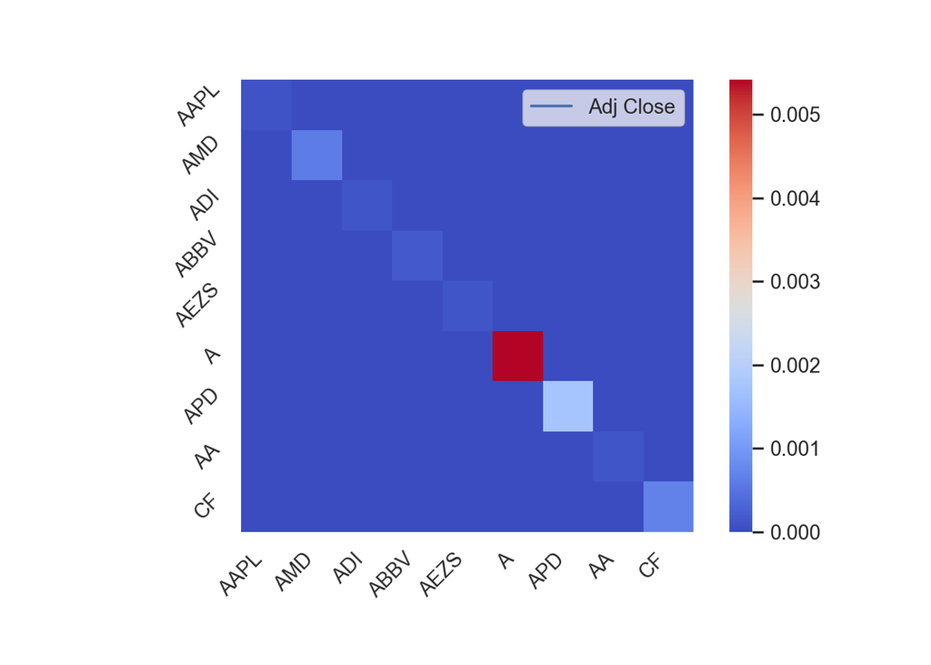

```python
from matplotlib.colors import LogNorm

ax = sns.heatmap(
    Psi,
    cmap='coolwarm',
    square=True
)
ax.set_xticklabels(
    ax.get_xticklabels(),
    rotation=45,
    horizontalalignment='right'
);
ax.set_yticklabels(
    ax.get_xticklabels(),
    rotation=45,
    horizontalalignment='right'
);
plt.show()
```

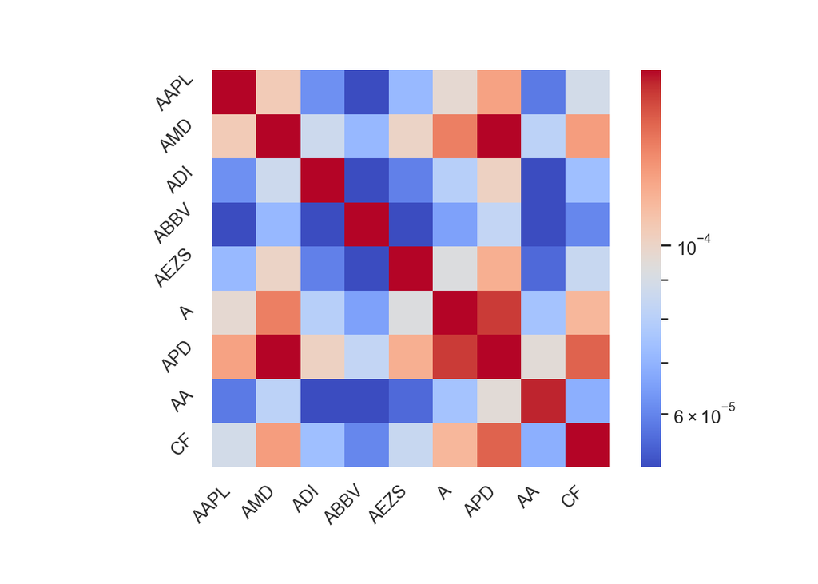

```python
ax = sns.heatmap(
    Sigma,
    cmap='coolwarm',
    square=True,
    norm=LogNorm(vmin=Sigma.min()[0], vmax=Sigma.max()[0])
)
ax.set_xticklabels(
    ax.get_xticklabels(),
    rotation=45,
    horizontalalignment='right'
);
ax.set_yticklabels(
    ax.get_xticklabels(),
    rotation=45,
    horizontalalignment='right'
);
plt.show()
```

Alternatively, we can do the fitting using a more compact matrix notation (recall time is along the vertical axis in $\mathbf{X}$)
$$\mathbf{X}^T = \boldsymbol{\alpha}\mathbf{1}^T +
\boldsymbol{\beta}\mathbf{f}^T + \mathbf{E}^T$$
and then write the LS fitting as
$$\underset{\boldsymbol{\alpha},\boldsymbol{\beta}}{\text{minimize}}\quad
\|\mathbf{X}^T - \boldsymbol{\alpha}\mathbf{1}^T -
\boldsymbol{\beta}\mathbf{f}^T\|^2_F.$$
More conveniently, we can define $\boldsymbol{\Gamma} = [ \boldsymbol{\alpha}, \boldsymbol{\beta} ]$ and the extended factors $\tilde{\mathbf{F}} = [\mathbf{1}, \mathbf{f}]$. The LS formulation can then be written as
$$\underset{\boldsymbol{\Gamma}}{\text{minimize}}\quad \|\mathbf{X}^T -
\boldsymbol{\Gamma}\tilde{\mathbf{F}}^T\|^2_F$$
with solution
$$\boldsymbol{\Gamma} = \mathbf{X}^T \tilde{\mathbf{F}}
(\tilde{\mathbf{F}}^T \tilde{\mathbf{F}})^{-1}$$

```python
F_ = np.column_stack([np.ones(len(f)), f])
Gamma_mat = np.linalg.solve(F_.T @ F_, F_.T @ X)
Gamma = pd.DataFrame(Gamma_mat.T, columns = ["alpha", "beta"])
alpha = Gamma["alpha"]
beta = Gamma["beta"]
print(Gamma)
#>       alpha      beta
#> 0  0.000281  1.327718
#> 1  0.000643  1.859352
#> 2  0.000400  1.095790
#> 3  0.000668  0.902275
#> 4  0.000361  1.268304
#> 5 -0.002209  1.711576
#> 6  0.001383  2.173830
#> 7  0.000150  1.027058
#> 8 -0.000626  1.571276
E = (np.asarray(X.T) - np.asarray(Gamma @ F_.T)).T
Psi = E.T @ E / (T - 2)
Sigma = np.cov(f, f)[0, 0] * np.asarray(beta).T @ np.asarray(beta) + np.diag(np.diag(Psi_mat))
```

### Assessing investment funds

In this example, we will assess the performance of several investment funds based on factor models. We will use the S&P 500 as the explicit market factor and assume a zero risk-free return $r_f=0$. In particular, we will consider the following six Exchange-Traded Funds (ETFs):

- SPY - SPDR S&P 500 ETF (index tracking)
- XIVH - Velocity VIX Short Vol Hedged (high alpha)
- SPHB - PowerShares S&P 500 High Beta Portfolio (high beta)
- SPLV - PowerShares S&P 500 Low Volatility Portfolio (low beta)
- USMV - iShares Edge MSCI Min Vol USA ETF
- JKD - iShares Morningstar Large-Cap ETF

We start by loading the data:

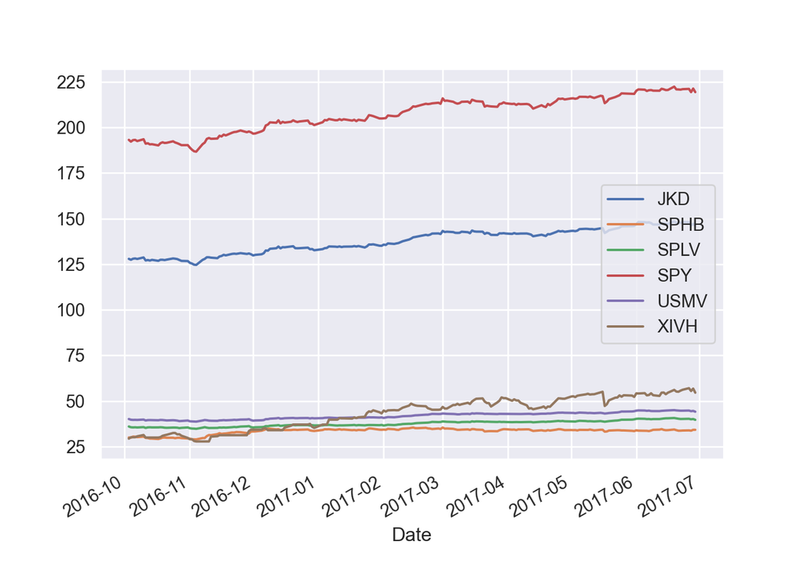

```python
begin_date = "2016-10-01"
end_date = "2017-06-30"
etf_namelist = ["SPY","XIVH", "SPHB", "SPLV", "USMV", "JKD"]
dataset = yf.download(etf_namelist,
                      start = begin_date,
                      end = end_date)[['Adj Close']]
#>
[                       0%                       ]
[****************      33%                       ]  2 of 6 completed
[**********************50%                       ]  3 of 6 completed
[**********************67%*******                ]  4 of 6 completed
[**********************83%***************        ]  5 of 6 completed
[*********************100%***********************]  6 of 6 completed
dataset.head()
#>                             Adj Close             ...
#>                                   JKD       SPHB  ...       USMV   XIVH
#> Date                                              ...
#> 2016-10-03 00:00:00-04:00  127.959999  30.023415  ...  40.154293  29.40
#> 2016-10-04 00:00:00-04:00  127.459999  29.941217  ...  39.762630  30.16
#> 2016-10-05 00:00:00-04:00  128.029999  30.516651  ...  39.673611  30.16
#> 2016-10-06 00:00:00-04:00  128.179993  30.452713  ...  39.700317  30.16
#> 2016-10-07 00:00:00-04:00  127.910004  30.215235  ...  39.655815  30.67
#>
#> [5 rows x 6 columns]
dataset.tail()
#>                             Adj Close             ...
#>                                   JKD       SPHB  ...       USMV       XIVH
#> Date                                              ...
#> 2017-06-23 00:00:00-04:00  148.119995  33.839931  ...  44.721642  56.200001
#> 2017-06-26 00:00:00-04:00  148.050003  33.913944  ...  44.793659  57.060001
#> 2017-06-27 00:00:00-04:00  146.290207  33.747421  ...  44.447994  55.512001
#> 2017-06-28 00:00:00-04:00  147.179993  34.237713  ...  44.610874  56.830002
#> 2017-06-29 00:00:00-04:00  146.089996  34.237713  ...  44.167496  54.590000
#>
#> [5 rows x 6 columns]
dataset.xs('Adj Close',axis=1).plot()
#> <AxesSubplot: xlabel='Date'>
plt.show()
```

```python
X = dataset[['Adj Close']].apply(np.log).apply(np.diff).xs('Adj Close',axis=1)
sp500 = yf.download("^GSPC", start = begin_date, end = end_date)
#>
[*********************100%***********************]  1 of 1 completed
T, N = X.shape  # number of days, number of etfs
f = sp500[['Adj Close']].apply(np.log).apply(np.diff).xs('Adj Close', axis=1)
```

Now we can compute the alpha and beta of all the ETFs:

```python
F_ = np.column_stack([np.ones(len(f)), f])
Gamma_mat = np.linalg.solve(F_.T @ F_, F_.T @ X)
Gamma = pd.DataFrame(Gamma_mat.T, columns = ["alpha", "beta"], index = etf_namelist)
Gamma
#>          alpha      beta
#> SPY   0.000163  0.904771
#> XIVH -0.000242  1.561353
#> SPHB  0.000107  0.677707
#> SPLV  0.000071  1.007143
#> USMV  0.000117  0.651162
#> JKD   0.001810  2.497109
```

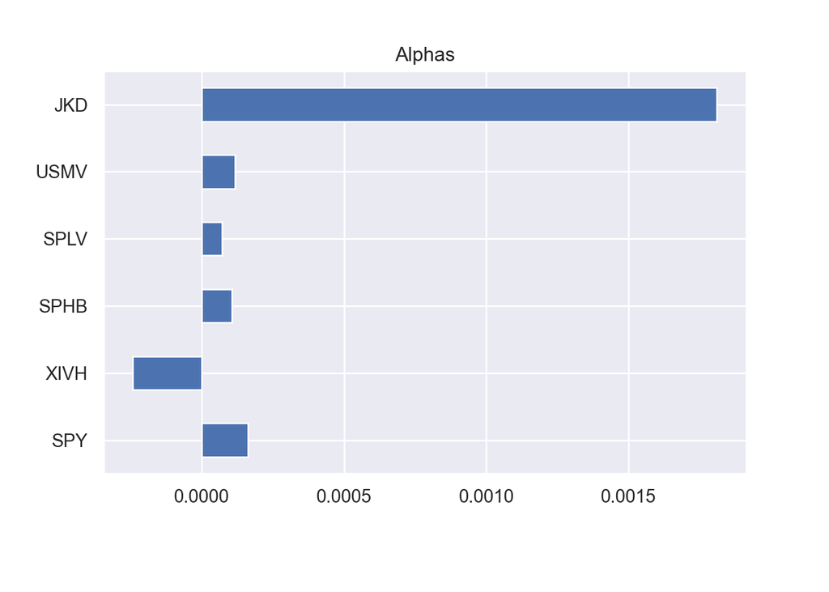

```python
Gamma['alpha'].plot.barh(title="Alphas")
#> <AxesSubplot: title={'center': 'Alphas'}>
plt.show()
```

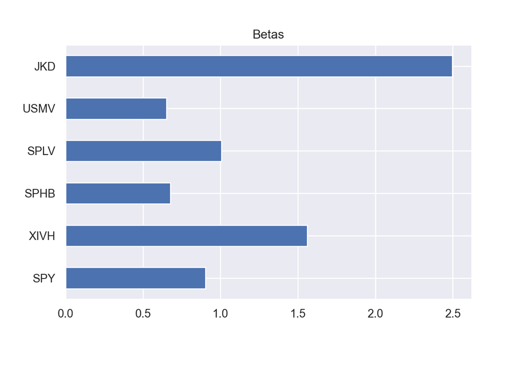

```python
Gamma['beta'].plot.barh(title="Betas")
#> <AxesSubplot: title={'center': 'Betas'}>
plt.show()
```

## Statistical factor model

Let’s now consider statistical factor models or implicit factor models where both the factors and the loadings are not available. Recall the principal factor method for the model $\mathbf{X}^T = \boldsymbol{\alpha}\mathbf{1}^T + \mathbf{B}\mathbf{F}^T + \mathbf{E}^T$ with $K$ factors:

1. PCA:
   - sample mean: $\hat{\boldsymbol{\alpha}} = \bar{\mathbf{x}} = \frac{1}{T}\mathbf{X}^T\mathbf{1}_T$
   - demeaned matrix: $\bar{\mathbf{X}} = \mathbf{X} - \mathbf{1}_T\bar{\mathbf{x}}^T$
   - sample covariance matrix: $\hat{\boldsymbol{\Sigma}} = \frac{1}{T-1}\bar{\mathbf{X}}^T\bar{\mathbf{X}}$
   - eigen-decomposition: $\hat{\boldsymbol{\Sigma}} = \hat{\boldsymbol{\Gamma}} \hat{\boldsymbol{\Lambda}} \hat{\boldsymbol{\Gamma}}^T$
2. Estimates:
   - $\hat{\mathbf{B}} = \hat{\boldsymbol{\Gamma}_1} \hat{\boldsymbol{\Lambda}}_1^{1/2}$
   - $\hat{\boldsymbol{\Psi}} = {\sf Diag}\left(\hat{\boldsymbol{\Sigma}} - \hat{\mathbf{B}} \hat{\mathbf{B}}^T\right)$
   - $\hat{\boldsymbol{\Sigma}} = \hat{\mathbf{B}} \hat{\mathbf{B}}^T + \hat{\boldsymbol{\Psi}}$
3. Update the eigen-decomposition: $\hat{\boldsymbol{\Sigma}} - \hat{\boldsymbol{\Psi}} = \hat{\boldsymbol{\Gamma}} \hat{\boldsymbol{\Lambda}} \hat{\boldsymbol{\Gamma}}^T$
4. Repeat Steps 2-3 until convergence.

```python
from sklearn.preprocessing import scale

K = 3
alpha = np.mean(X, axis=0)
X_ = scale(X, with_std=False)
Sigma_prev = np.zeros((N, N))
Psi = np.zeros((N, N))
Sigma = X_.T @ X_ / (T-1)
while (np.linalg.norm(Sigma - Sigma_prev)/np.linalg.norm(Sigma) > 1e-3):
  values, vectors = np.linalg.eig(Sigma - Psi)
  B = vectors[:, :K] * np.sqrt(values[:K])
  Psi = np.diag(np.diag(Sigma - B @ B.T))
  Sigma_prev = Sigma
  Sigma = B @ B.T + Psi
#> <string>:3: RuntimeWarning: invalid value encountered in sqrt
pd.DataFrame(np.column_stack([alpha, B]).real, index=etf_namelist) # remove imaginary part due to overflow during evd
#>              0         1         2   3
#> SPY   0.000712 -0.002694 -0.002867 NaN
#> XIVH  0.000706 -0.004794 -0.007496 NaN
#> SPHB  0.000519 -0.001245 -0.002399 NaN
#> SPLV  0.000683 -0.002765 -0.003632 NaN
#> USMV  0.000512 -0.001296 -0.002229 NaN
#> JKD   0.003327 -0.023771  0.002506 NaN
```

# Shrinkage estimators

This section will illustrate the incorporation of prior information in the estimation of $\boldsymbol{\mu}$ and $\boldsymbol{\Sigma}$.

Suppose we have an $N$-dimensional i.i.d. Gaussian time series
$$\mathbf{x}_t \sim \mathcal{N}(\boldsymbol{\mu}, \boldsymbol{\Sigma}).$$
The sample estimators for the mean and covariance matrix are, respectively, the sample mean
$$\hat{\boldsymbol{\mu}} = \frac{1}{T}\sum_{t=1}^T \mathbf{x}_t$$
and the sample covariance matrix
$$\hat{\boldsymbol{\Sigma}} = \frac{1}{T-1}\sum_{t=1}^T (\mathbf{x}_t -
\hat{\boldsymbol{\mu}})^T(\mathbf{x}_t - \hat{\boldsymbol{\mu}}).$$
We will next explore the idea of shrinkage in order to improve those sample estimators when $T$ is not large enough.

## Shrinkage for $\boldsymbol{\mu}$

The James-Stein estimator is
$$\hat{\boldsymbol{\mu}}^\textsf{JS} = (1-\rho) \hat{\boldsymbol{\mu}} +
\rho \mathbf{t}$$
where $\mathbf{t}$ is the shrinkage target and $0\le\rho\le1$ is the amount of shrinkage. Common choices for the target $\mathbf{t}$ are:

- $\mathbf{t} = \mathbf{0}$
- $\mathbf{t} = 0.1 \times \mathbf{1}$
- $\mathbf{t} = \frac{\mathbf{1}^T \hat{\boldsymbol{\mu}}}{N} \times \mathbf{1}$ (grand mean target)
- $\mathbf{t} = \frac{\mathbf{1}^T\hat{\boldsymbol{\Sigma}}^{-1}\hat{\boldsymbol{\mu}}}{\mathbf{1}^T\hat{\boldsymbol{\Sigma}}^{-1}\mathbf{1}} \times \mathbf{1}$ (volatility-weighted mean)

A choice of $\rho$ that improves the estimatior error is
$$\rho =
\frac{1}{T}\frac{N\bar{\boldsymbol{\lambda}}-2\boldsymbol{\lambda}_\textsf{max}}{\|\hat{\boldsymbol{\mu}}
- \mathbf{t}\|^2}$$
where $\bar{\boldsymbol{\lambda}}$ and $\boldsymbol{\lambda}_\textsf{max}$ are the average and maximum values, respectively, of the eigenvalues of $\boldsymbol{\Sigma}$ (or $\hat{\boldsymbol{\Sigma}}$).

We will first explore this estimator using synthetic data. Let’s start generating the data:

```python
# generate Gaussian synthetic return data
np.random.seed(42)
N = 100
T = 120
mu = np.random.uniform(size=N)
U = np.random.multivariate_normal(mean=np.zeros(N), cov=0.1*np.eye(N), size=round(0.7*N)).T
Sigma = U @ U.T + np.eye(N)
X = np.random.multivariate_normal(mean=mu, cov=Sigma, size=T)

# sample estimates (sample mean and sample covariance matrix)
mu_sm     = np.mean(X, axis=0)
Sigma_scm = np.cov(X.T)
```

Now let’s try the James-Stein estimator with the four targets:

```python
# define the four targets
t_1 = np.zeros(N)
t_2 = 0.1 * np.ones(N)
t_3 = np.mean(mu_sm) * np.ones(N)
t_4 = np.sum(np.linalg.solve(Sigma_scm, mu_sm)/np.sum(np.linalg.solve(Sigma_scm, np.ones(N))))*np.ones(N)

# compute the corresponding four rho's
lambdas, _ = np.linalg.eig(Sigma_scm)
lmd_mean = np.mean(lambdas)
lmd_max = np.max(lambdas)
rho_1 = (1/T)*(N*lmd_mean - 2*lmd_max)/np.linalg.norm(mu_sm - t_1)**2
rho_2 = (1/T)*(N*lmd_mean - 2*lmd_max)/np.linalg.norm(mu_sm - t_2)**2
rho_3 = (1/T)*(N*lmd_mean - 2*lmd_max)/np.linalg.norm(mu_sm - t_3)**2
rho_4 = (1/T)*(N*lmd_mean - 2*lmd_max)/np.linalg.norm(mu_sm - t_4)**2

# finally the James-Stein estimators
mu_JS_1 = (1-rho_1)*mu_sm + rho_1*t_1
mu_JS_2 = (1-rho_2)*mu_sm + rho_2*t_2
mu_JS_3 = (1-rho_3)*mu_sm + rho_3*t_3
mu_JS_4 = (1-rho_4)*mu_sm + rho_4*t_4
```

Let’s now compare the estimation error measured in terms of squared error and PRIAL (percentage relative improvement in average loss):
$$\begin{align}
\textsf{SE} &= \|\hat{\boldsymbol{\mu}}^\textsf{JS} -
\boldsymbol{\mu}\|^2\\
\textsf{PRIAL} &= \frac{\|\hat{\boldsymbol{\mu}} -
\boldsymbol{\mu}\|^2 - \|\hat{\boldsymbol{\mu}}^\textsf{JS} -
\boldsymbol{\mu}\|^2}{\|\hat{\boldsymbol{\mu}} - \boldsymbol{\mu}\|^2}
\end{align}$$

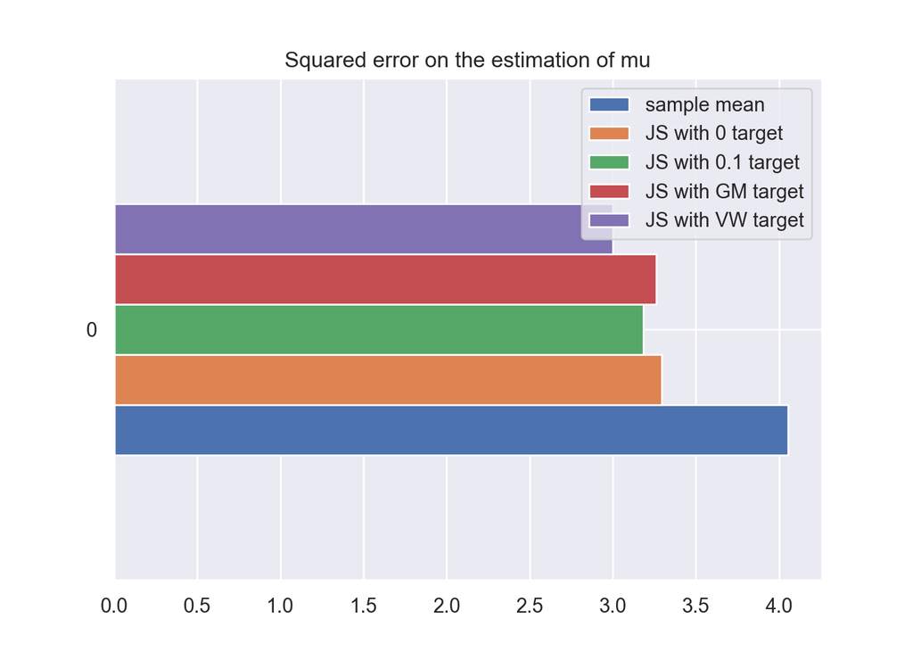

```python
# compute squared error and PRIAL
SE_mu = np.array([np.linalg.norm(mu_sm   - mu)**2,
                  np.linalg.norm(mu_JS_1 - mu)**2,
                  np.linalg.norm(mu_JS_2 - mu)**2,
                  np.linalg.norm(mu_JS_3 - mu)**2,
                  np.linalg.norm(mu_JS_4 - mu)**2])
names = ["sample mean", "JS with 0 target", "JS with 0.1 target",
         "JS with GM target", "JS with VW target"]
ref = np.linalg.norm(mu_sm - mu)**2
PRIAL_mu = (ref - SE_mu)/ref

# plots
pd.DataFrame(SE_mu.reshape((-1, 5)), columns=names).plot.barh(title="Squared error on the estimation of mu")
#> <AxesSubplot: title={'center': 'Squared error on the estimation of mu'}>
plt.show()
```

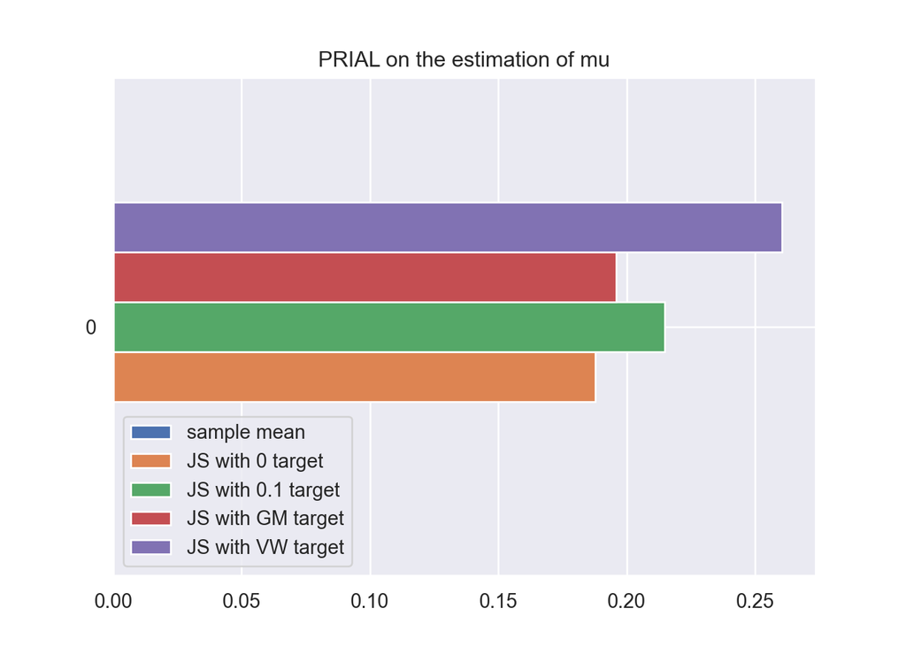

```python
pd.DataFrame(PRIAL_mu.reshape((-1, 5)), columns=names).plot.barh(title="PRIAL on the estimation of mu")
#> <AxesSubplot: title={'center': 'PRIAL on the estimation of mu'}>
plt.show()
```

The improvement in performance is quite clear. We can now plot the error as a function of the number of samples to get a more complete picture:

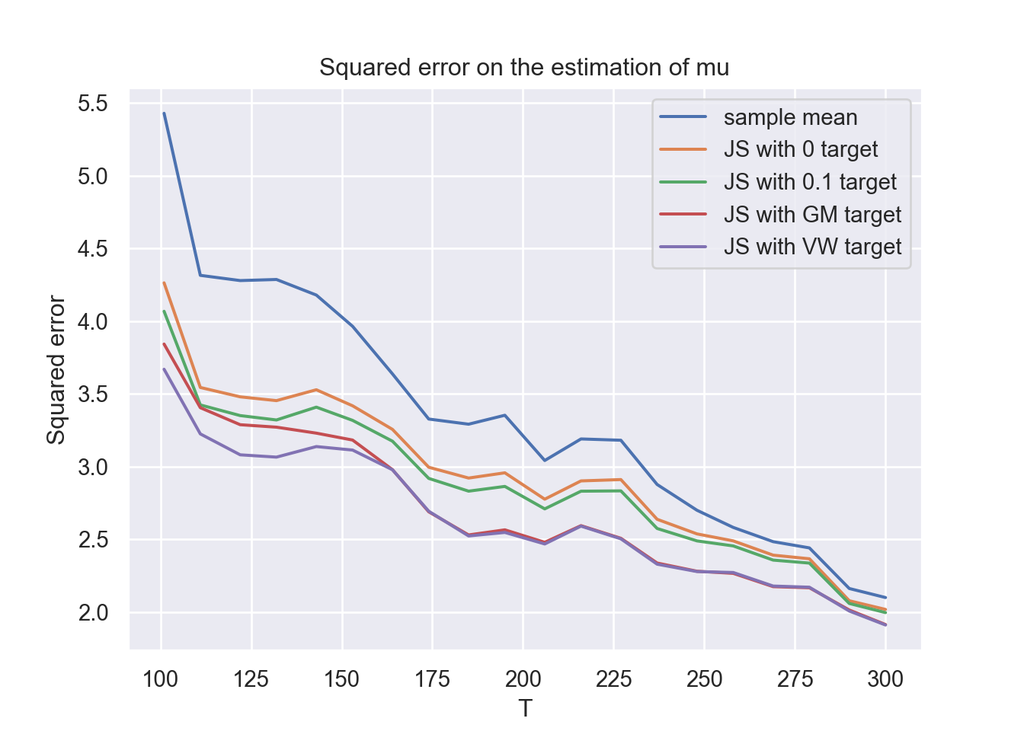

```python
# first generate all the data
np.random.seed(42)
N = 100
T_max = 300
mu = np.random.uniform(size=N)
U = np.random.multivariate_normal(mean=np.zeros(N), cov=0.1*np.eye(N), size=round(0.7*N)).T
Sigma = U @ U.T + np.eye(N)
X = np.random.multivariate_normal(mean=mu, cov=Sigma, size=T_max)

# now loop over subsets of the samples
SE_mu_vs_T = []
T_sweep = np.round(np.linspace(1.01*N, T_max, 20))
for T in T_sweep.astype(int):
  X_ = X[:T,]
  # sample estimates
  mu_sm     = np.mean(X_, axis=0)
  Sigma_scm = np.cov(X_.T)
  # James-Stein estimators
  t_1 = np.zeros(N)
  t_2 = 0.1 * np.ones(N)
  t_3 = np.mean(mu_sm) * np.ones(N)
  t_4 = np.sum(np.linalg.solve(Sigma_scm, mu_sm)/np.sum(np.linalg.solve(Sigma_scm, np.ones(N))))*np.ones(N)
  lambdas, _ = np.linalg.eig(Sigma_scm)
  lmd_mean = np.mean(lambdas)
  lmd_max = np.max(lambdas)
  rho_1 = (1/T)*(N*lmd_mean - 2*lmd_max)/np.linalg.norm(mu_sm - t_1)**2
  rho_2 = (1/T)*(N*lmd_mean - 2*lmd_max)/np.linalg.norm(mu_sm - t_2)**2
  rho_3 = (1/T)*(N*lmd_mean - 2*lmd_max)/np.linalg.norm(mu_sm - t_3)**2
  rho_4 = (1/T)*(N*lmd_mean - 2*lmd_max)/np.linalg.norm(mu_sm - t_4)**2
  mu_JS_1 = (1-rho_1)*mu_sm + rho_1*t_1
  mu_JS_2 = (1-rho_2)*mu_sm + rho_2*t_2
  mu_JS_3 = (1-rho_3)*mu_sm + rho_3*t_3
  mu_JS_4 = (1-rho_4)*mu_sm + rho_4*t_4
  # compute errors
  SE_mu_vs_T.append([np.linalg.norm(mu_sm   - mu)**2, np.linalg.norm(mu_JS_1 - mu)**2,
                     np.linalg.norm(mu_JS_2 - mu)**2, np.linalg.norm(mu_JS_3 - mu)**2,
                     np.linalg.norm(mu_JS_4 - mu)**2])
SE_mu_vs_T = np.ascontiguousarray(SE_mu_vs_T)
df = pd.DataFrame(SE_mu_vs_T, columns = names, index = T_sweep.astype(int))
df.plot()
#> <AxesSubplot: >
plt.xlabel("T")
#> Text(0.5, 0, 'T')
plt.ylabel("Squared error")
#> Text(0, 0.5, 'Squared error')
plt.title("Squared error on the estimation of mu")
#> Text(0.5, 1.0, 'Squared error on the estimation of mu')
plt.show()
# compute PRIAL
#PRIAL_mu_vs_T <- (SE_mu_vs_T[, 1] - SE_mu_vs_T[, -1])/SE_mu_vs_T[, 1]
```

## Shrinkage for $\boldsymbol{\Sigma}$

The shrinkage estimator for the covariance matrix is
$$\hat{\boldsymbol{\Sigma}}^\textsf{sh} = (1-\rho)
\hat{\boldsymbol{\Sigma}} + \rho \mathbf{T}$$
where $\mathbf{T}$ is the shrinkage target and $0\le\rho\le1$ is the amount of shrinkage.

Common choices for the target $\mathbf{T}$ are:

- $\mathbf{T} = \frac{1}{N}\textsf{Tr}\left(\hat{\boldsymbol{\Sigma}}\right) \times \mathbf{I}$ (scaled identity)
- $\mathbf{T} = \textsf{Diag}(\hat{\boldsymbol{\Sigma}})$ (diagonal)

To determine $\rho$ we will use three different criteria via random matrix theory (RMT):

- MSE of covariance matrix
- quadratic loss of precision matrix
- Sharpe ratio.

Let’s start by generating some synthetic data:

```python
# generate Gaussian synthetic return data
np.random.seed(42)
N = 100
T = 120
mu = np.random.uniform(size=N)
U = np.random.multivariate_normal(mean=np.zeros(N), cov=0.1*np.eye(N), size=round(0.7*N)).T
Sigma = U @ U.T + np.eye(N)
X = np.random.multivariate_normal(mean=mu, cov=Sigma, size=T)

# sample estimates (sample mean and sample covariance matrix)
mu_sm     = np.mean(X, axis=0)
Sigma_scm = np.cov(X.T)
```

The two targets are easily computed:

```python
# two target matrices T=Identity and T=Diagonal
T_I = np.sum(np.diag(Sigma_scm))/N * np.eye(N)
T_D = np.diag(np.diag(Sigma_scm))
```

### Ledoit-Wolf shrinkage

We next compute the Ledoit-Wolf estimator:
$$\rho =\min\left(1,\frac{\frac{1}{T^{2}}\sum_{t=1}^{T}||\hat{\boldsymbol{\Sigma}}-\mathbf{r}_{t}\mathbf{r}_{t}^{T}||_{F}^{2}}{||\hat{\boldsymbol{\Sigma}}-\mathbf{T}||_{F}^{2}}\right)$$

```python
# Ledoit-Wolf shrinkage estimators with two targets
def rho_LW(X, Sigma_scm, Sigma_T):
    X = scale(X, with_std=False)
    T = X.shape[0]
    tmp = (1-T)*np.linalg.norm(Sigma_scm)**2 + np.sum(np.apply_along_axis(np.linalg.norm, 1, X)**4)
    rho = np.min([1, (1./T**2) * tmp / np.linalg.norm(Sigma_scm - Sigma_T)**2])
    return rho

rho = rho_LW(X, Sigma_scm, T_I)
Sigma_LW_I = (1-rho)*Sigma_scm + rho*T_I
rho = rho_LW(X, Sigma_scm, T_D)
Sigma_LW_D = (1-rho)*Sigma_scm + rho*T_D
```

Let’s now compare the estimation error measured in terms of squared error and PRIAL:
$$\begin{align}
\textsf{SE} &= \|\hat{\boldsymbol{\Sigma}}^\textsf{sh} -
\boldsymbol{\Sigma}\|_F^2\\
\textsf{PRIAL} &= \frac{\|\hat{\boldsymbol{\Sigma}} -
\boldsymbol{\Sigma}\|_F^2 - \|\hat{\boldsymbol{\Sigma}}^\textsf{sh} -
\boldsymbol{\Sigma}\|_F^2}{\|\hat{\boldsymbol{\Sigma}} -
\boldsymbol{\Sigma}\|_F^2}
\end{align}$$

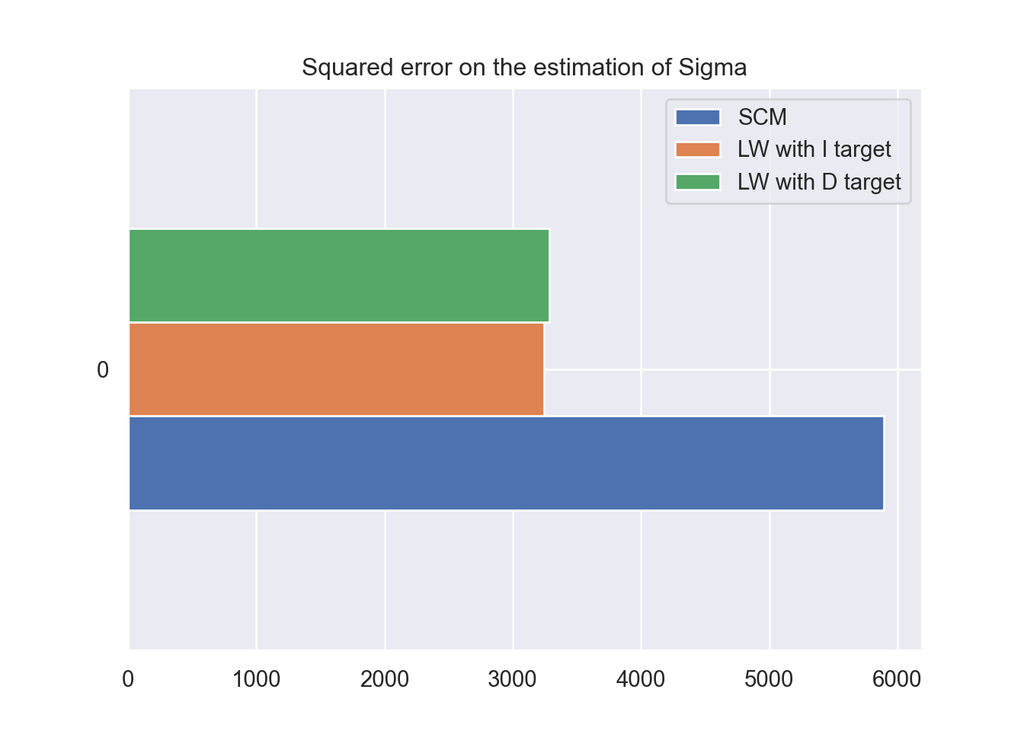

```python
# performance in terms of squared error and PRIAL
SE_Sigma = np.array([np.linalg.norm(Sigma_scm  - Sigma)**2,
                     np.linalg.norm(Sigma_LW_I - Sigma)**2,
                     np.linalg.norm(Sigma_LW_D - Sigma)**2])
names = ["SCM", "LW with I target", "LW with D target"]
ref = np.linalg.norm(Sigma_scm - Sigma)**2
PRIAL_Sigma = (ref - SE_Sigma) / ref

pd.DataFrame(SE_Sigma.reshape((-1, 3)), columns=names).plot.barh(title="Squared error on the estimation of Sigma")
#> <AxesSubplot: title={'center': 'Squared error on the estimation of Sigma'}>
plt.show()
```

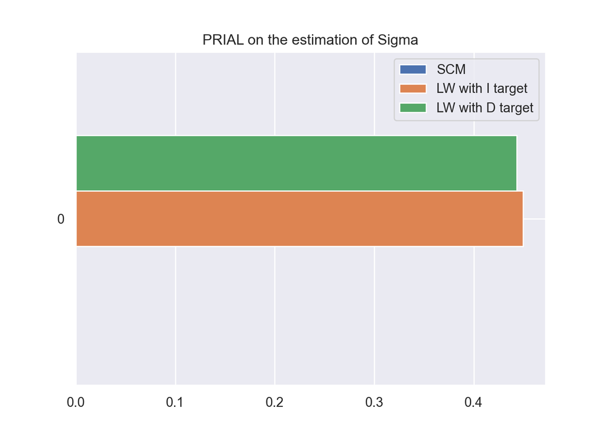

```python
pd.DataFrame(PRIAL_Sigma.reshape((-1, 3)), columns=names).plot.barh(title="PRIAL on the estimation of Sigma")
#> <AxesSubplot: title={'center': 'PRIAL on the estimation of Sigma'}>
plt.show()
```

### Max-SR shrinkage

Let’s try now the shrinkage estimator based on maximizing the Sharpe ratio:
$$\begin{array}{ll}
\underset{\rho_{1}\geq0}{\textsf{maximize}} & \begin{array}{c}
\frac{\hat{\boldsymbol{\mu}}^{T}(\hat{\boldsymbol{\Sigma}}^{\textsf{sh}})^{-1}\hat{\boldsymbol{\mu}}-\delta}{\sqrt{b\hat{\boldsymbol{\mu}}^{T}(\hat{\boldsymbol{\Sigma}}^{\textsf{sh}})^{-1}\hat{\boldsymbol{\Sigma}}(\hat{\boldsymbol{\Sigma}}^{\textsf{sh}})^{-1}\hat{\boldsymbol{\mu}}}}\end{array}\\
\textsf{subject to} & \begin{array}[t]{l}
\hat{\boldsymbol{\Sigma}}^{\textsf{sh}}=\rho_{1}\mathbf{T}+\hat{\boldsymbol{\Sigma}}\\
\delta=D/(1-D)\\
D=\frac{1}{T}\textsf{Tr}(\hat{\boldsymbol{\Sigma}}(\hat{\boldsymbol{\Sigma}}^{\textsf{sh}})^{-1})\\
b=\frac{T}{\textsf{Tr}(\mathbf{W}(\mathbf{I}+\delta\mathbf{W})^{-2})}
\end{array}
\end{array}$$
where $\mathbf{W}=\mathbf{I}-\frac{1}{T}\mathbf{1}\mathbf{1}^{T}$.

```python
def rho_maxSR(mu_sm, Sigma_scm, Sigma_T, T):
    W = np.eye(T) - np.ones(T*T).reshape((T, T))/T
    rho1_sweep = np.exp(np.linspace(-10, 10, 100))
    obj = []
    for rho1 in rho1_sweep:
        Sigma_sh = rho1 * Sigma_T + Sigma_scm
        D = (1/T)*np.sum(np.diag(Sigma_scm @ np.linalg.solve(Sigma_sh, np.eye(len(Sigma_sh)))))
        delta = D / (1 - D)
        B = np.linalg.solve((np.eye(T)+delta*W) @ (np.eye(T)+delta*W), np.eye(len(W)))
        b = T / np.sum(np.diag(W @ B))
        inv_S_sh_mu = np.linalg.solve(Sigma_sh, mu_sm).reshape((1, Sigma_sh.shape[0]))
        num = np.sum(mu_sm * inv_S_sh_mu) - delta
        den = np.sqrt(b * inv_S_sh_mu @ Sigma_scm @ inv_S_sh_mu.T)
        obj.append(num/den)
    i_max = np.argmax(obj)
    rho1 = rho1_sweep[i_max]
    return (rho1/(1 + rho1))

rho = rho_maxSR(mu_sm, Sigma_scm, T_I, T)
Sigma_maxSR_I = (1-rho)*Sigma_scm + rho*T_I
rho = rho_maxSR(mu_sm, Sigma_scm, T_D, T)
Sigma_maxSR_D = (1-rho)*Sigma_scm + rho*T_D
```

We can now evaluate the performance:

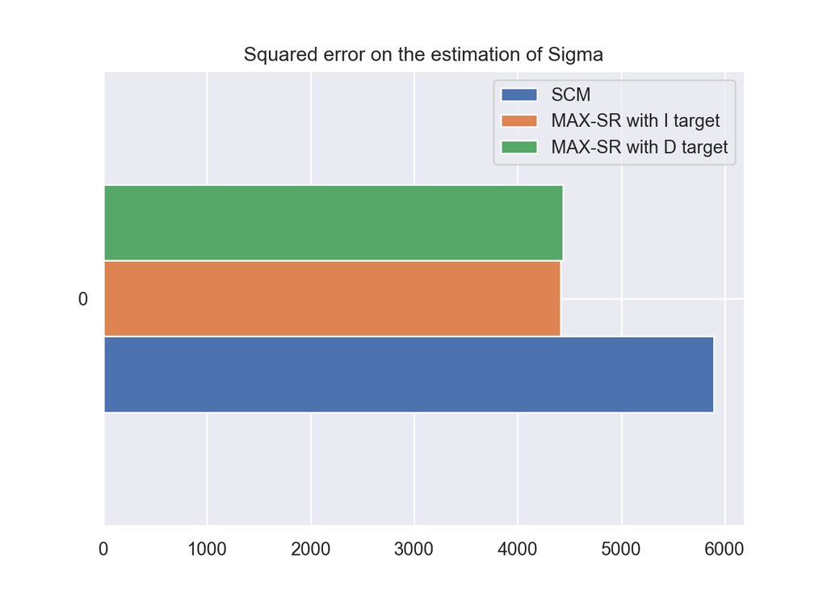

```python
SE_Sigma = np.array([np.linalg.norm(Sigma_scm  - Sigma)**2,
                     np.linalg.norm(Sigma_maxSR_I - Sigma)**2,
                     np.linalg.norm(Sigma_maxSR_D - Sigma)**2])
names = ["SCM", "MAX-SR with I target", "MAX-SR with D target"]
ref = np.linalg.norm(Sigma_scm - Sigma)**2
PRIAL_Sigma = (ref - SE_Sigma) / ref

pd.DataFrame(SE_Sigma.reshape((-1, 3)), columns=names).plot.barh(title="Squared error on the estimation of Sigma")
#> <AxesSubplot: title={'center': 'Squared error on the estimation of Sigma'}>
plt.show()
```

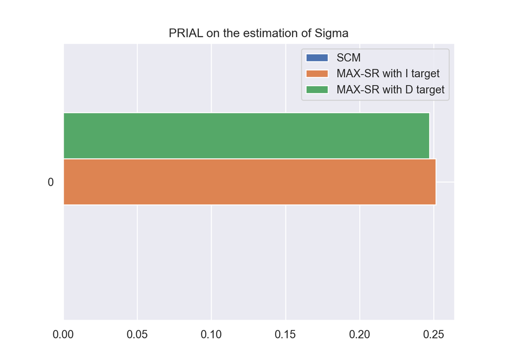

```python
pd.DataFrame(PRIAL_Sigma.reshape((-1, 3)), columns=names).plot.barh(title="PRIAL on the estimation of Sigma")
#> <AxesSubplot: title={'center': 'PRIAL on the estimation of Sigma'}>
plt.show()
```

Let’s also compute the Sharpe ratio:

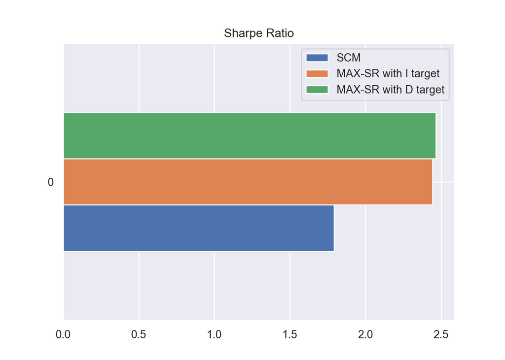

```python
def compute_SR(Sigma_scm, mu_sm, mu, Sigma):
    inv_S_sh_mu = np.linalg.solve(Sigma_scm, mu_sm).reshape((-1, len(Sigma_scm)))
    return np.sum(mu * inv_S_sh_mu) / np.sqrt(inv_S_sh_mu @ Sigma @ inv_S_sh_mu.T)

SR_Sigma = np.array([compute_SR(Sigma_scm, mu_sm, mu, Sigma),
                     compute_SR(Sigma_maxSR_I, mu_sm, mu, Sigma),
                     compute_SR(Sigma_maxSR_D, mu_sm, mu, Sigma)])

pd.DataFrame(SR_Sigma.reshape((-1, 3)), columns=names).plot.barh(title="Sharpe Ratio")
#> <AxesSubplot: title={'center': 'Sharpe Ratio'}>
plt.show()
```

### Comparison

We can now plot the performance measures as a function of the number of samples to get a more complete picture (we will use only the identity target):

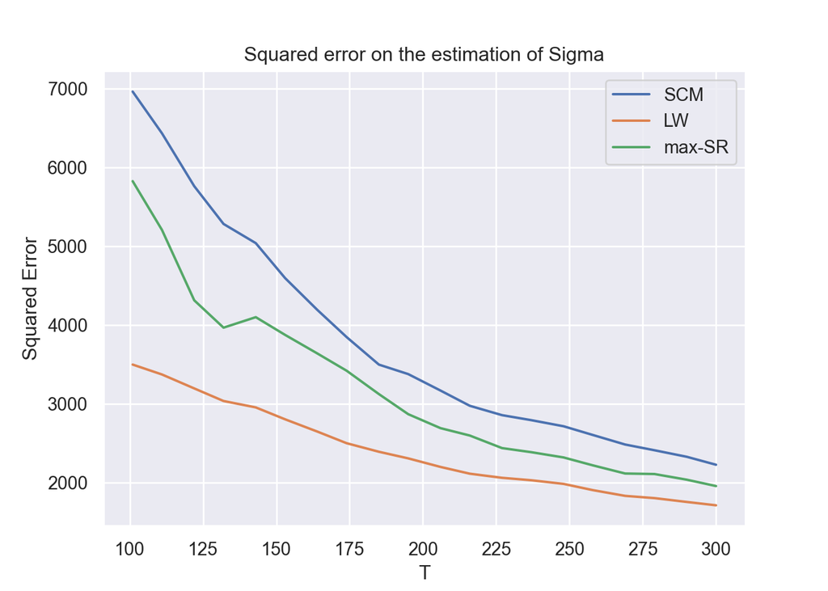

```python
# first generate all the data
np.random.seed(42)
N = 100
T_max = 300
mu = np.random.uniform(size=N)
U = np.random.multivariate_normal(mean=np.zeros(N), cov=0.1*np.eye(N), size=round(0.7*N)).T
Sigma = U @ U.T + np.eye(N)
X = np.random.multivariate_normal(mean=mu, cov=Sigma, size=T_max)

# now loop over subsets of the samples
SE_mu_vs_T = []
T_sweep = np.round(np.linspace(1.01*N, T_max, 20))

SR_Sigma_vs_T = []
SE_Sigma_vs_T = []

for T in T_sweep.astype(int):
    X_ = X[:T,]
    # sample estimates
    mu_sm = np.mean(X_, axis=0)
    Sigma_scm = np.cov(X_.T)
    T_I = np.eye(N) * np.sum(np.diag(Sigma_scm))/N
    rho = rho_LW(X_, Sigma_scm, T_I)
    Sigma_LW = (1-rho)*Sigma_scm + rho*T_I
    rho = rho_maxSR(mu_sm, Sigma_scm, T_I, T)
    Sigma_maxSR = (1-rho)*Sigma_scm + rho*T_I
    # compute performance
    SE_Sigma_vs_T.append([np.linalg.norm(Sigma_scm   - Sigma)**2,
                          np.linalg.norm(Sigma_LW    - Sigma)**2,
                          np.linalg.norm(Sigma_maxSR - Sigma)**2])
    SR_Sigma_vs_T.append([compute_SR(Sigma_scm,   mu_sm, mu, Sigma),
                          compute_SR(Sigma_LW,    mu_sm, mu, Sigma),
                          compute_SR(Sigma_maxSR, mu_sm, mu, Sigma)])
SE_Sigma_vs_T = np.ascontiguousarray(SE_Sigma_vs_T)
SR_Sigma_vs_T = np.ascontiguousarray(SR_Sigma_vs_T).reshape((20, 3))

names = ["SCM", "LW", "max-SR"]
pd.DataFrame(SE_Sigma_vs_T, columns=names, index=T_sweep.astype(int)).plot(title="Squared error on the estimation of Sigma")
#> <AxesSubplot: title={'center': 'Squared error on the estimation of Sigma'}>
plt.xlabel("T")
#> Text(0.5, 0, 'T')
plt.ylabel("Squared Error")
#> Text(0, 0.5, 'Squared Error')
plt.show()
```

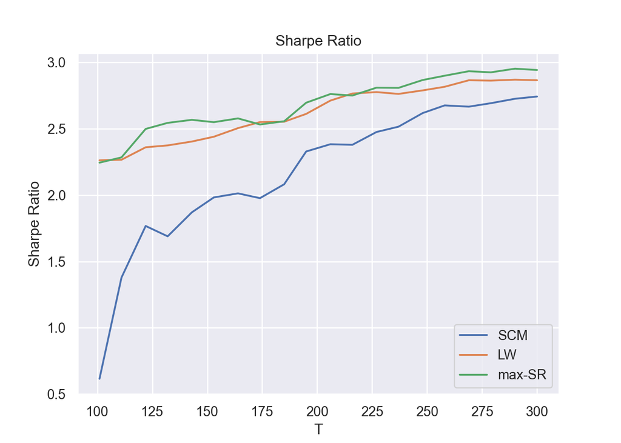

```python
pd.DataFrame(SR_Sigma_vs_T, columns=names, index=T_sweep.astype(int)).plot(title="Sharpe Ratio")
#> <AxesSubplot: title={'center': 'Sharpe Ratio'}>
plt.xlabel("T")
#> Text(0.5, 0, 'T')
plt.ylabel("Sharpe Ratio")
#> Text(0, 0.5, 'Sharpe Ratio')
plt.show()
```

# Robust estimators to heavy tails

This section will illustrate the need for heavy-tailed estimators when it comes to financial data.

## Estimator for $\boldsymbol{\Sigma}$

We will first consider the estimation of $\boldsymbol{\Sigma}$ via Tyler’s estimator assuming that the mean is zero (or known and previously removed).

Recall that the sample covariance matrix is
$$\boldsymbol{\Sigma} = \frac{1}{T}\sum_{t=1}^T\mathbf{x}_t\mathbf{x}_t^T$$
whereas the Tyler estimator is the solution to the fixed-point equation:
$$\boldsymbol{\Sigma} =
\frac{N}{T}\sum_{t=1}^T\frac{\mathbf{x}_t\mathbf{x}_t^T}{\mathbf{x}_t^T\boldsymbol{\Sigma}^{-1}\mathbf{x}_t},$$
which requires an iterative algorithm in practice.

Let’s code it in the following function:

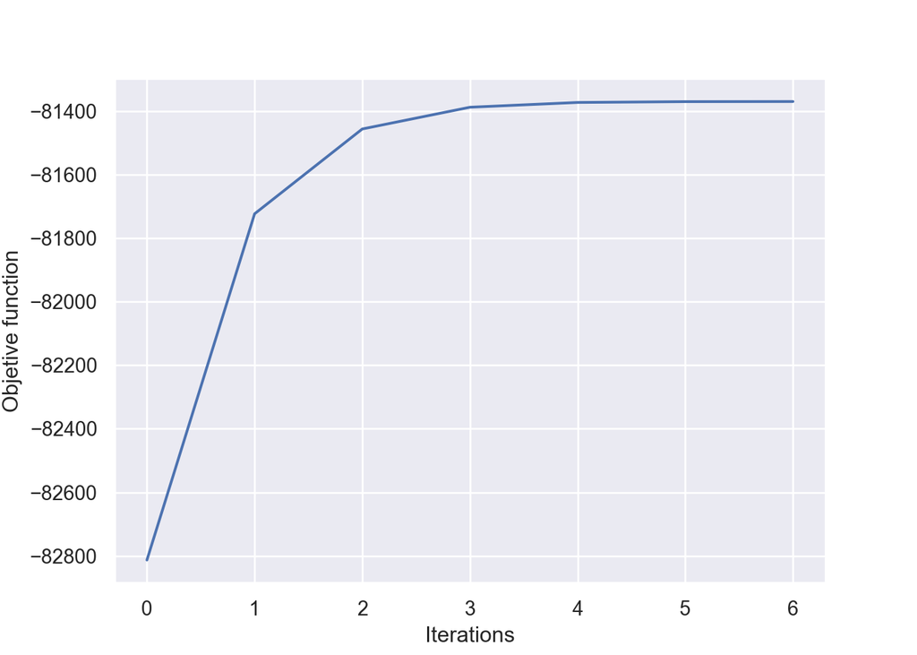

```python
def estimate_tyler(X, verbose=False):
    T, N = np.shape(X)
    max_iter = 100
    error_th_Sigma = 1e-3
    # Gaussian initial point
    Sigma = np.cov(X.T)
    Sigma = Sigma/sum(np.diag(Sigma))
    #loop
    obj_value_record = np.empty(max_iter)
    Sigma_diff_record = np.empty(max_iter)
    for k in range(max_iter):
        Sigma_prev = np.copy(Sigma)
        # Tyler update
        Sigma_inv = np.linalg.solve(Sigma, np.eye(Sigma.shape[0]))
        weights = 1/np.diag(X @ Sigma_inv @ X.T)
        obj_value_record[k] = (N/2)*np.sum(np.log(weights)) - (T/2)*np.sum(np.log(np.linalg.eig(Sigma)[0].real))
        Sigma = (N/T) * X.T @ np.diag(weights) @ X
        Sigma = Sigma/np.sum(np.diag(Sigma))
        # stopping criterion
        Sigma_diff_record[k] = np.linalg.norm(Sigma - Sigma_prev) / np.linalg.norm(Sigma_prev)
        if (Sigma_diff_record[k] < error_th_Sigma):
            break
    obj_value_record = obj_value_record[:k]
    Sigma_diff_record = Sigma_diff_record[:k]
    # finally, recover missing scaling factor
    sigma2 = np.apply_along_axis(np.var, 0, X)
    d = np.diag(Sigma)
    kappa = np.sum(sigma2*d)/np.sum(d*d)
    if verbose:
        #sns.lineplot(np.arange(k), obj_value_record)
        plt.plot(np.arange(k), obj_value_record)
        plt.xlabel("Iterations")
        plt.ylabel("Objetive function")
        plt.show()
    return kappa*Sigma

np.random.seed(42)
N = 100
T = 300
mu = np.zeros(N)
U = np.random.multivariate_normal(mean=np.zeros(N), cov=0.1*np.eye(N), size=round(0.7*N)).T
Sigma_cov = U @ U.T + np.eye(N)
nu = 4
X = multivariate_t(mean=mu, cov=(nu-2)/nu*Sigma_cov, nu=nu, size=T)

Sigma_tyler = estimate_tyler(X, verbose=True)
```

```python
Sigma_classical = np.cov(X.T)

np.linalg.norm(Sigma_cov - Sigma_tyler) / np.linalg.norm(Sigma_cov)
#> 0.4178242612293536
np.linalg.norm(Sigma_cov - Sigma_classical) / np.linalg.norm(Sigma_cov)
#> 0.8844023458889887
```

It is now clear that Tyler’s estimator is much better than the naive sample covariance matrix when the data is heavy-tailed.

But what if the data was Gaussian? What would be the penalty for using Tyler when the sample covariance matrix would have been perfectly fine?

```python
X = np.random.multivariate_normal(mean=mu, cov=Sigma_cov, size=T)
Sigma_tyler = estimate_tyler(X)
Sigma_classical = np.cov(X.T)

np.linalg.norm(Sigma - Sigma_tyler) / np.linalg.norm(Sigma)
#> 1.0796066830805728
np.linalg.norm(Sigma - Sigma_classical) / np.linalg.norm(Sigma)
#> 1.0781340031931597
```

Interestingly, we virtually don’t really lose anything! So we better stick to heavy-tailed estimators all the time, just in case, just to be safe.

## Estimator for $\boldsymbol{\mu}$ and then $\boldsymbol{\Sigma}$

Now will consider the estimation of $\boldsymbol{\mu}$ and then $\boldsymbol{\Sigma}$ in two stages: first $\boldsymbol{\mu}$ and then $\boldsymbol{\Sigma}$ via Tyler’s estimator.

Let’s generate heavy-tailed data with a nonzero mean:

```python
mu = np.random.normal(size=N)  # nonzero mean!
U = np.random.multivariate_normal(mean=np.zeros(N), cov=0.1*np.eye(N), size=round(0.7*N)).T
Sigma_cov = U @ U.T + np.eye(N)
X = multivariate_t(mean=mu, cov=(nu-2)/nu*Sigma_cov, nu=nu, size=T)

# estimators assuming wrongly zero-mean
Sigma_classical = X.T @ X / (T - 1)
Sigma_tyler = estimate_tyler(X)

np.linalg.norm(Sigma_cov - Sigma_tyler) / np.linalg.norm(Sigma_cov)
#> 1.149183411686039
np.linalg.norm(Sigma_cov - Sigma_classical) / np.linalg.norm(Sigma_cov)
#> 0.9740460924030309
```

We need to demean or center the data. Let’s use the sample mean
$$\boldsymbol{\mu} =
\frac{1}{T}\sum_{t=1}^T\mathbf{x}_t.$$

```python
# let's remove the mean first
mu_classical = np.mean(X, axis=0)
np.linalg.norm(mu_classical - mu)
#> 1.458061761012409
X_ = X - mu_classical

# then estimate the covariance matrix
Sigma_classical = (1/(T-1)) * X_.T @ X_
Sigma_tyler = estimate_tyler(X_)
np.linalg.norm(Sigma_cov - Sigma_tyler) / np.linalg.norm(Sigma_cov)
#> 0.37832279285021864
np.linalg.norm(Sigma_cov - Sigma_classical) / np.linalg.norm(Sigma_cov)
#> 0.4987136705319818
```

However, the sample mean is not robust for heavy-tailed distributions, so we could use a robust estimator like the median:

```python
# let's remove the median now
mu_median = np.median(X, axis=0)
np.linalg.norm(mu_median - mu)
#> 1.4467323844546998
X_ = X - mu_median

# then estimate the covariance matrix
Sigma_classical = X_.T @ X / (T-1)
Sigma_tyler = estimate_tyler(X_)
np.linalg.norm(Sigma_cov - Sigma_tyler) / np.linalg.norm(Sigma_cov)
#> 0.3775557992752501
np.linalg.norm(Sigma_cov - Sigma_classical) / np.linalg.norm(Sigma_cov)
#> 0.5088392776129118
```

We don’t observe any significant improvement from using the median instead of the mean. We can try a more sophisticated robust estimation of the mean: the geometric median (aka spatial median).

The geometric median of a discrete set of sample points in a Euclidean space is the point minimizing the sum of distances to the sample points:
$$\underset{\boldsymbol{\mu}}{\text{minimize}}\quad
\sum_{t=1}^T\|\mathbf{x}_t-\boldsymbol{\mu}\|$$
For the 1-dimensional case, it becomes the traditional median.

Let’s try the geometric median then:

```python
from scipy.optimize import minimize
from scipy.spatial.distance import cdist

def compute_geometric_median(X):
    return minimize(lambda x: cdist([x], X).sum(), np.mean(X, axis=0), method='powell').x

mu_gmedian = compute_geometric_median(X)
np.linalg.norm(mu_gmedian - mu)
#> 1.0772061757278562
X_ = X - mu_gmedian

# then estimate the covariance matrix
Sigma_classical = X_.T @ X / (T-1)
Sigma_tyler = estimate_tyler(X_)
np.linalg.norm(Sigma_cov - Sigma_tyler) / np.linalg.norm(Sigma_cov)
#> 0.3775893882670286
np.linalg.norm(Sigma_cov - Sigma_classical) / np.linalg.norm(Sigma_cov)
#> 0.5030453970037209
```

The estimation of the $\mathbf{\mu}$ has been significantly improved, but the estimation of the covariance matrix $\mathbf{\Sigma}$ does not seem to be improved.

## Joint Estimator for $\boldsymbol{\mu}$ and $\boldsymbol{\Sigma}$

Until now, we have first estimated the mean vector (with estimators like the sample mean, median, and geometric median) and then the covariance matrix (with estimators like the sample covariance matrix and Tyler’s estimtor). In principle, this two-step procedure does not have to be optimal. We will now try a joint estimation of the mean vector and the covariance matrix under a heavy-tailed distribution via the Student-$t$’s maximum likelihood estimation (MLE). The algorithm becomes a bit more involved and we will not code it ourselves; instead we will use the R package [`fitHeavyTail`](https://cran.r-project.org/package=fitHeavyTail).

```r
library(fitHeavyTail)  # for Student-t estimation
library(mvtnorm)
library(reticulate)

# generate heavy-tailed synthetic return data
set.seed(237)
nu <- 4
N <- 200
T <- 300
mu <- rnorm(N)
U <- t(rmvnorm(n = round(0.7*N), sigma = 0.1*diag(N)))
Sigma_cov <- U %*% t(U) + diag(N)
X <- rmvt(n = T, delta = mu, sigma = (nu-2)/nu*Sigma_cov, df = nu)

# estimate the mean vector
mu_mean    <- colMeans(X)
mu_median  <- apply(X, 2, median)
mu_gmedian <- ICSNP::spatial.median(X)
norm(mu_mean    - mu, "2")
```

```
#> [1] 3.329964
```

```r
norm(mu_median  - mu, "2")
```

```
#> [1] 3.230282
```

```r
norm(mu_gmedian - mu, "2")
```

```
#> [1] 2.443257
```

```r
# estimate the covariance matrix
Sigma_SCM <- cov(X)
norm(Sigma_SCM - Sigma_cov, "F")
```

```
#> [1] 300.798
```

```r
X_ <- X - rep(mu_gmedian, each = T)
Sigma_tyler <- py$estimate_tyler(X_)
norm(Sigma_tyler - Sigma_cov, "F")
```

```
#> [1] 180.678
```

```r
# joint estimation of mean vector and covariance matrix
fitted <- fit_mvt(X)
norm(fitted$mu - mu, "2")
```

```
#> [1] 2.29107
```

```r
norm(fitted$cov - Sigma_cov, "F")
```

```
#> [1] 198.4872
```

## Comparison

```r
library(mvtnorm)  # for heavy-tailed generation
library(fitHeavyTail)  # for Student-t estimation

# parameters
set.seed(237)
nu <- 4
N <- 40
mu <- rnorm(N)
U <- t(rmvnorm(n = round(0.7*N), sigma = 0.1*diag(N)))
Sigma_cov <- U %*% t(U) + diag(N)

# main loop
T_sweep <- seq(from = 20, to = 600, by = 20)
error_mu_mean <- error_mu_median <- error_mu_gmedian <- error_mu_Student_t <- rep(NA, length(T_sweep))
error_Sigma_Tyler <- error_Sigma_Student_t <- error_Sigma_SCM <- rep(NA, length(T_sweep))
for(k in 1:length(T_sweep)) {
  T <- T_sweep[k]

  # generate heavy-tailed data
  X <- rmvt(n = T, delta = mu, sigma = (nu-2)/nu*Sigma_cov, df = nu)

  # estimation of mu
  mu_mean    <- colMeans(X)
  mu_median  <- apply(X, 2, median)
  mu_gmedian <- ICSNP::spatial.median(X)
  error_mu_mean[k]    <- norm(mu_mean    - mu, "2")
  error_mu_median[k]  <- norm(mu_median  - mu, "2")
  error_mu_gmedian[k] <- norm(mu_gmedian - mu, "2")

  # estimation of Sigma
  # SCM
  Sigma_SCM <- cov(X)
  error_Sigma_SCM[k] <- norm(Sigma_SCM - Sigma_cov, "F")

  # Tyler
  X_ <- X - rep(mu_gmedian, each = T)
  if (T > N) {
    Sigma_tyler <- py$estimate_tyler(X_)
    error_Sigma_Tyler[k] <- norm(Sigma_tyler - Sigma_cov, "F")
  }

  # Student-t
  if (T > N) {
    res_Student_t   <- fit_mvt(X)
    mu_Student_t    <- res_Student_t$mu
    Sigma_Student_t <- res_Student_t$cov
    error_Sigma_Student_t[k] <- norm(Sigma_Student_t - Sigma_cov, "F")
    error_mu_Student_t[k]    <- norm(mu_Student_t - mu, "2")
  }
}
```

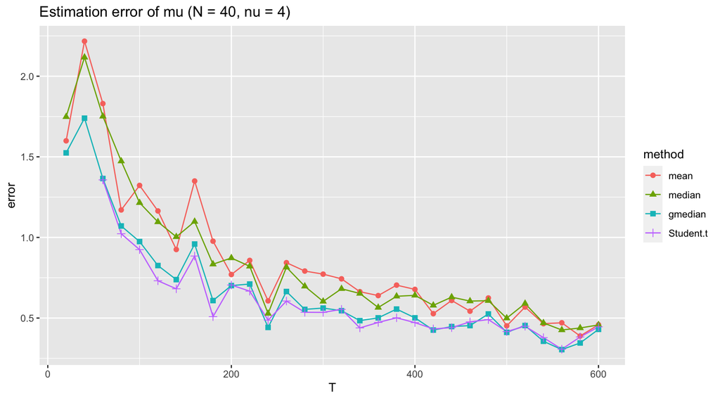

```r
library(ggplot2)
library(reshape2)

# plot error in mu
df_mu <- data.frame(T           = T_sweep,
                    "mean"      = error_mu_mean,
                    "median"    = error_mu_median,
                    "gmedian"   = error_mu_gmedian,
                    "Student-t" = error_mu_Student_t)
df_molten_mu <- melt(df_mu, id.vars = "T", variable.name = "method")
ggplot(df_molten_mu, aes(x = T, y = value, col = method, shape = method)) +
  geom_line() + geom_point(size = 2) +
  ggtitle(sprintf("Estimation error of mu (N = %d, nu = %d)", N, nu)) + ylab("error")
```

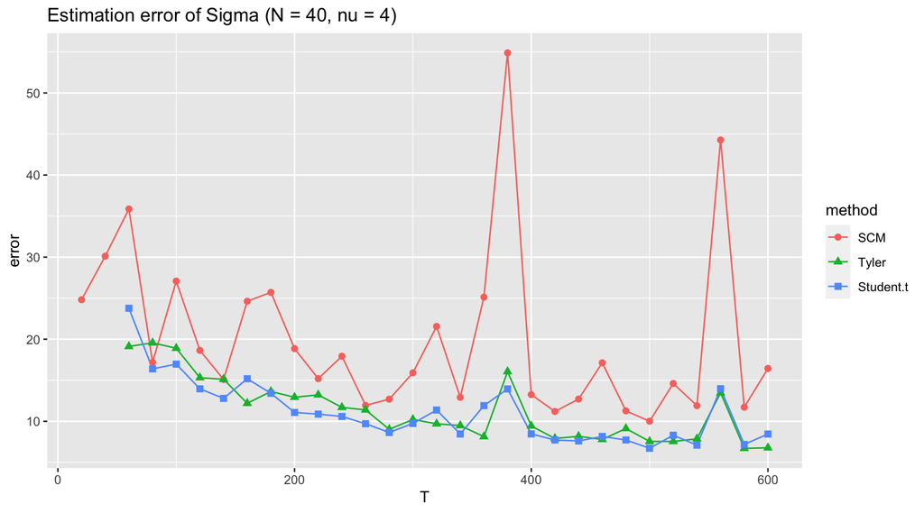

```r
# plot error in Sigma
df_Sigma <- data.frame(T           = T_sweep,
                       "SCM"       = error_Sigma_SCM,
                       "Tyler"     = error_Sigma_Student_t,
                       "Student-t" = error_Sigma_Tyler)
df_molten_Sigma <- melt(df_Sigma, id.vars = "T", variable.name = "method")
ggplot(df_molten_Sigma, aes(x = T, y = value, col = method, shape = method)) +
  geom_line() + geom_point(size = 2) +
  ggtitle(sprintf("Estimation error of Sigma (N = %d, nu = %d)", N, nu)) + ylab("error")
```